# Análisis evolución Covid-19 Chile casos y decesos (14/04/2020)

Claudio Bustos

14/4/2020

- Reportes anteriores: https://github.com/clbustos/analisis_covid19_chile

## Análisis de series de casos

La serie de casos se hace hace partir de los 25 casos, excepto para Atacama y Aysén, donde se inicia del quinto caso, para facilitar la comparación desde un punto de un punto de partida común. En la serie total se nota una leve desaceleración, pero en la Región Metropolitana incluso se nota una curva un tanto acelerada los últimos 5 días.

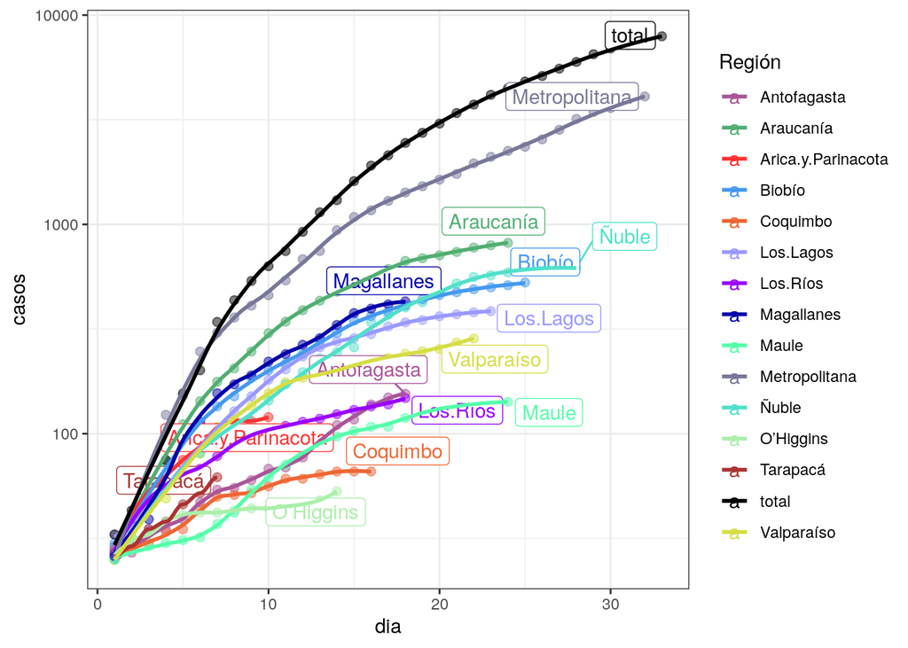

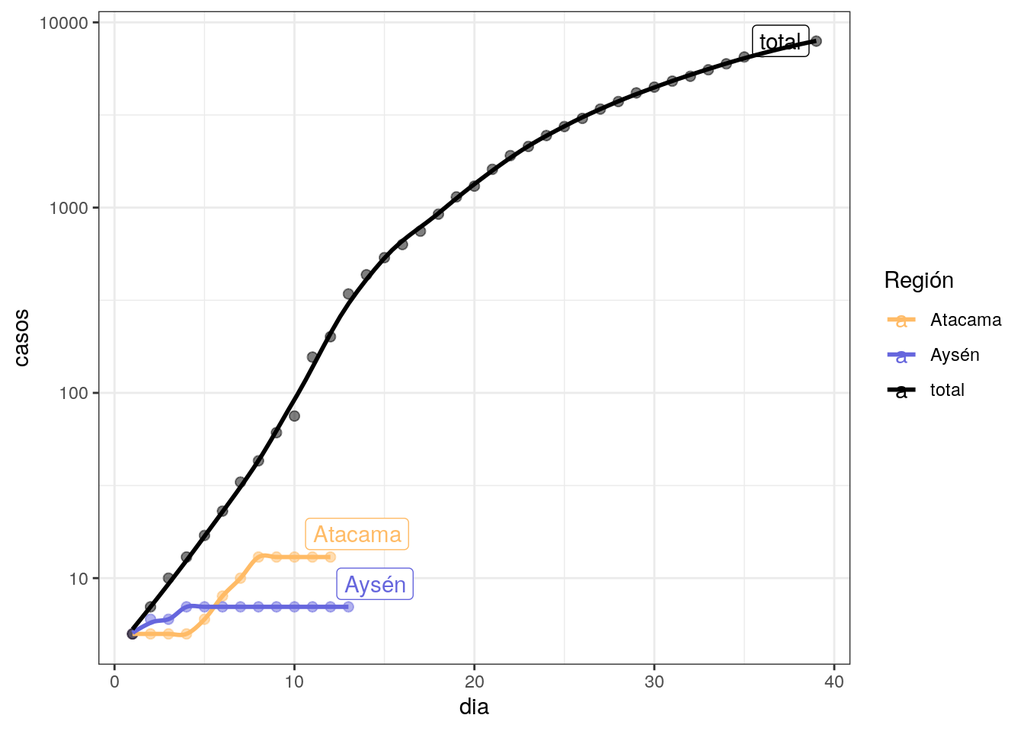

La serie por región se hace partir de los 5 primeros casos.

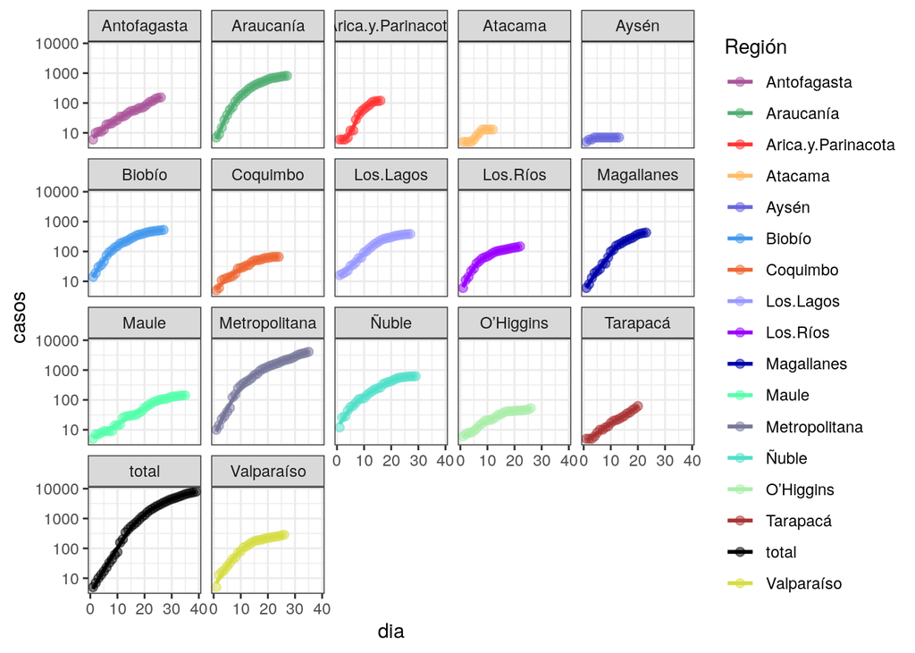

Una forma de objetivar el grado de aceleración o desaceleración de la curva completa es plotear el componente lineal (ascenso inicial) contra el componente cuadrático (curva de caída) de una regresión sobre el log. Un componente cuadrático cercano a cero indica que la curva ha permanecido constante durante todo el periodo; un valor positivo, que la tasa está acelerándose, vs un valor negativo, que indica desaceleración. Se observa una relación inversa entre ambos indicadores, es decir, una tasa más acelerada inicial implica una desaceleración más rápida, también. Entre los datos interesantes se puede encontrar Tarapacá, que presenta un comportamiento acelerado pese a su escasa cantidad de casos, así como Atacama, que presenta una progresión lineal relativamente rápida para el grupo, pero tambien una fuerte desaceleracion.

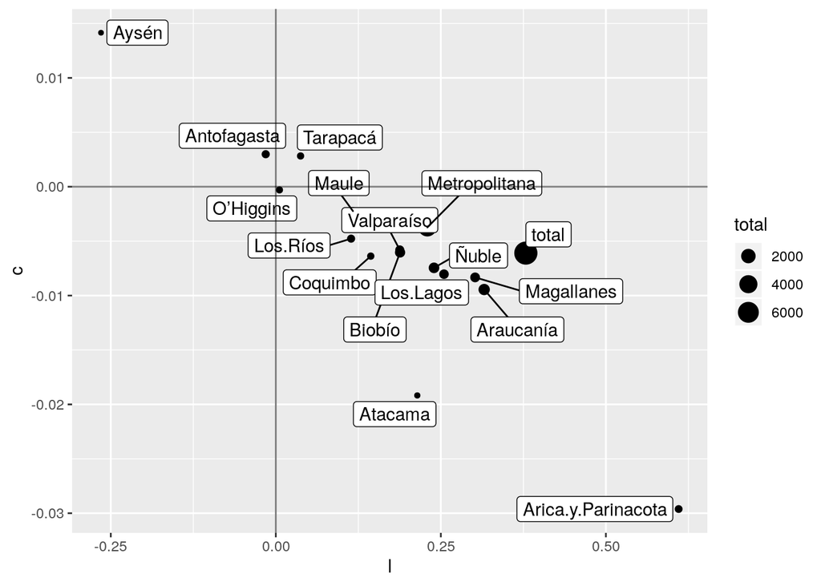

Podemos ver que en varias series nos estamos acercando a la deseada tasa 1 de casos en el tiempo *t* vs casos en tiempo *t-1*. En particular, Aysén hace varios días no presenta casos nuevos. Vemos que Tarapacá presenta una aceleración en el número de casos.

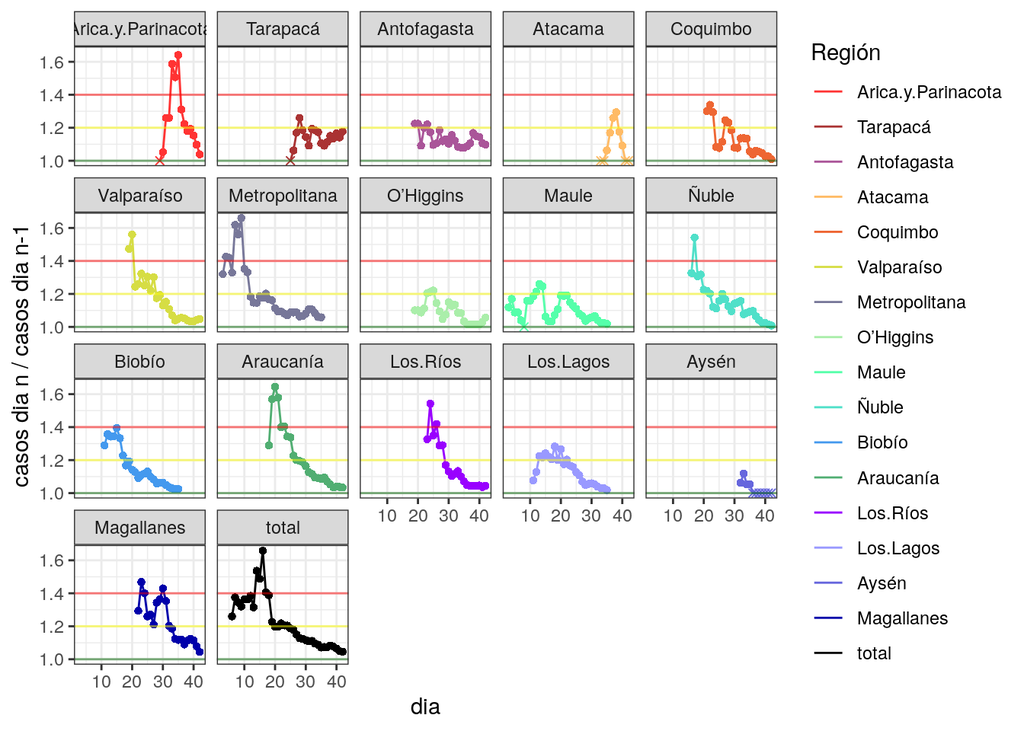

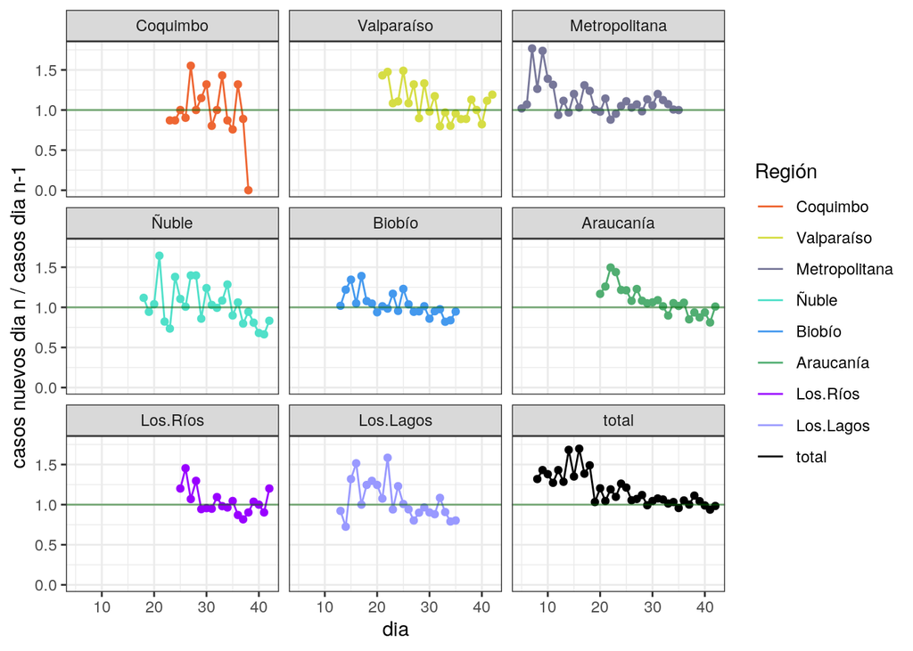

## Predicción

### Predicción para serie total

Recordemos que la regresión exponencial se eliminó, porque ya no calza con la serie total. A partir del análisis del resultado del algoritmo de la última semana, para la predicción total se recorta la serie a partir de lo 50 casos.

Como hicimos ayer, verifiquemos el desempeño de los algoritmos durante el presente periodo. Hace 6 días, se predijo para hoy 7085 y 7199 casos con AR(1) y AR(4), respectivamente, ambas predicciones bajo el valor observado, nuevamente, pero incluyendo el intervalo de confianza.

|  | casos | li | ls |
| --- | --- | --- | --- |
| **Observado** | 7917 | NA | NA |
| **ARIMA(1,1,0)** | 16132.48 | 6201.088 | 41969.56 |
| **T+AR(1)** | 7085.033 | 6309.284 | 8665.809 |
| **T+AR(4)** | 7199.054 | 6408.925 | 8760.855 |

Hoy, ya podemos ver que el modelo AR(4) se muestra más pesimista que AR(1), debido a la tendencia de aceleración de casos en los últimos días.

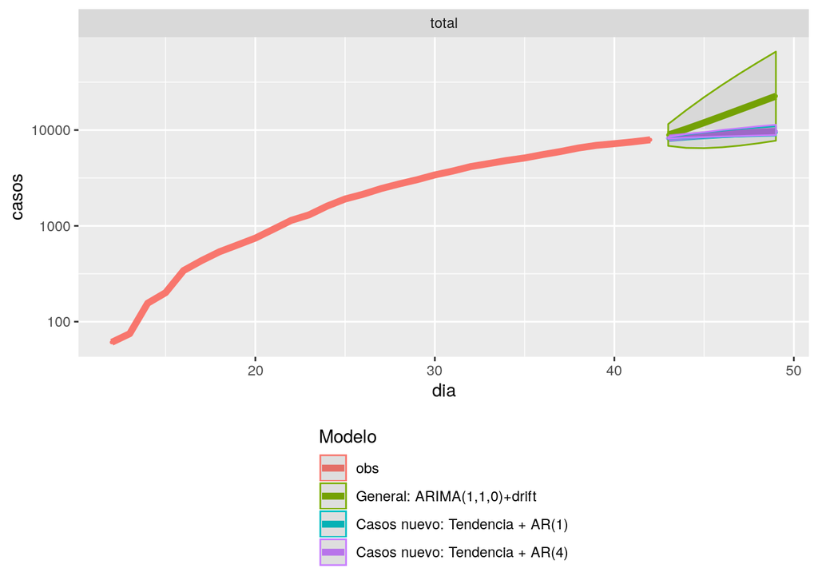

Casos nuevos: tendencia + AR(4) : total

|  | dia | casos | li | ls |
| --- | --- | --- | --- | --- |
| **32** | 43 | 8241 | 8113 | 8453 |
| **33** | 44 | 8596 | 8314 | 9079 |
| **34** | 45 | 8837 | 8448 | 9513 |
| **35** | 46 | 9091 | 8572 | 10035 |
| **36** | 47 | 9294 | 8668 | 10461 |
| **37** | 48 | 9520 | 8775 | 10938 |
| **38** | 49 | 9708 | 8861 | 11353 |

Casos nuevos: tendencia + AR(1) : total

|  | dia | casos | li | ls |
| --- | --- | --- | --- | --- |
| **32** | 43 | 8186 | 8068 | 8396 |
| **33** | 44 | 8476 | 8220 | 8949 |
| **34** | 45 | 8722 | 8347 | 9426 |
| **35** | 46 | 8954 | 8466 | 9878 |
| **36** | 47 | 9159 | 8571 | 10277 |
| **37** | 48 | 9343 | 8666 | 10636 |
| **38** | 49 | 9505 | 8749 | 10952 |

ARIMA(1,1,0) con deriva : total

|  | dia | casos | li | ls |
| --- | --- | --- | --- | --- |
| **32** | 43 | 8888 | 6841 | 11548 |
| **33** | 44 | 10247 | 6518 | 16111 |
| **34** | 45 | 11943 | 6472 | 22038 |
| **35** | 46 | 13982 | 6611 | 29571 |
| **36** | 47 | 16399 | 6886 | 39058 |
| **37** | 48 | 19249 | 7271 | 50959 |
| **38** | 49 | 22600 | 7756 | 65850 |

### Predicciones para serie total usando predicción por regiones.

Otro modelo posible de análisis es usar la suma de las predicciones parciales por región. No he calculado los intervalos de confianza, porque para que sean adecuados debería considerar la covarianza entre las series de las distintas regiones.

El modelo de sumas de T+AR(1) en 7 días predice 10661, prácticamente un 10% más que los modelos de serie total.

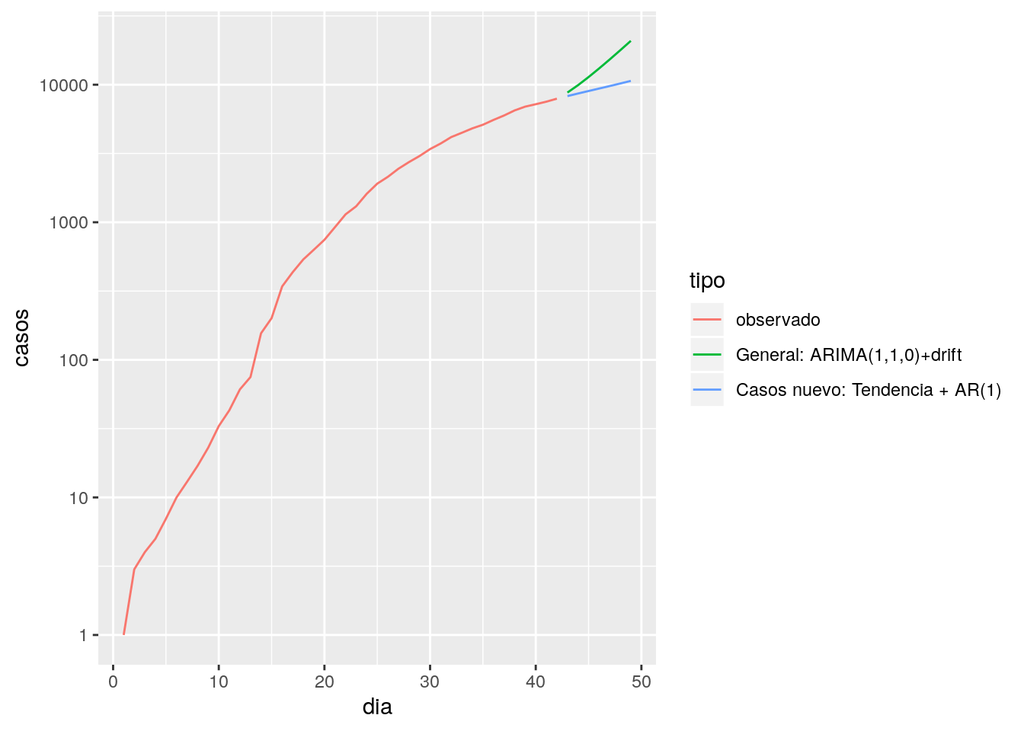

| dia | tipo | casos |
| --- | --- | --- |
| 1 | observado | 1 |
| 2 | observado | 3 |
| 3 | observado | 4 |
| 4 | observado | 5 |
| 5 | observado | 7 |
| 6 | observado | 10 |
| 7 | observado | 13 |
| 8 | observado | 17 |
| 9 | observado | 23 |
| 10 | observado | 33 |
| 11 | observado | 43 |
| 12 | observado | 61 |
| 13 | observado | 75 |
| 14 | observado | 156 |
| 15 | observado | 201 |
| 16 | observado | 342 |
| 17 | observado | 434 |
| 18 | observado | 537 |
| 19 | observado | 632 |
| 20 | observado | 746 |
| 21 | observado | 922 |
| 22 | observado | 1142 |
| 23 | observado | 1306 |
| 24 | observado | 1610 |
| 25 | observado | 1909 |
| 26 | observado | 2139 |
| 27 | observado | 2449 |
| 28 | observado | 2738 |
| 29 | observado | 3031 |
| 30 | observado | 3404 |
| 31 | observado | 3737 |
| 32 | observado | 4161 |
| 33 | observado | 4471 |
| 34 | observado | 4815 |
| 35 | observado | 5116 |
| 36 | observado | 5546 |
| 37 | observado | 5972 |
| 38 | observado | 6501 |
| 39 | observado | 6927 |
| 40 | observado | 7213 |
| 41 | observado | 7525 |
| 42 | observado | 7917 |
| 43 | General: ARIMA(1,1,0)+drift | 8767 |
| 44 | General: ARIMA(1,1,0)+drift | 9919 |
| 45 | General: ARIMA(1,1,0)+drift | 11365 |
| 46 | General: ARIMA(1,1,0)+drift | 13131 |
| 47 | General: ARIMA(1,1,0)+drift | 15257 |
| 48 | General: ARIMA(1,1,0)+drift | 17802 |
| 49 | General: ARIMA(1,1,0)+drift | 20836 |
| 43 | Casos nuevo: Tendencia + AR(1) | 8269 |
| 44 | Casos nuevo: Tendencia + AR(1) | 8628 |
| 45 | Casos nuevo: Tendencia + AR(1) | 8996 |
| 46 | Casos nuevo: Tendencia + AR(1) | 9378 |
| 47 | Casos nuevo: Tendencia + AR(1) | 9778 |
| 48 | Casos nuevo: Tendencia + AR(1) | 10203 |
| 49 | Casos nuevo: Tendencia + AR(1) | 10661 |

### Predicción por regiones

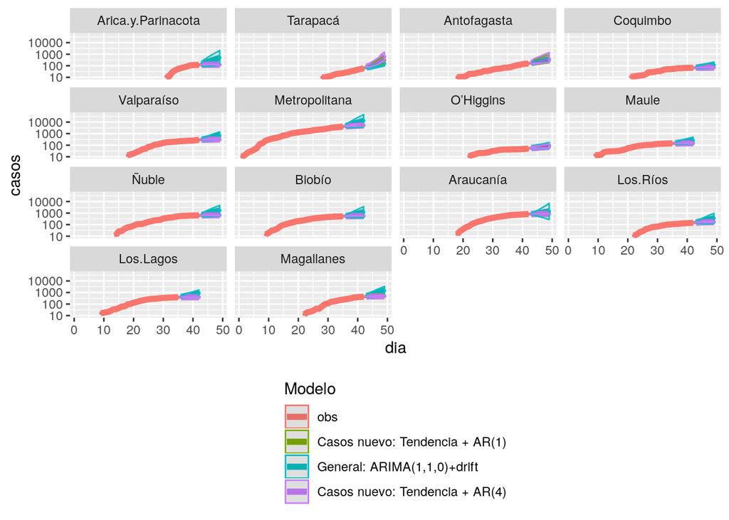

Las tablas por regiones se incluye en el Anexo I

## Decesos

Si observamos la serie de decesos, tanto la serie como total como para la Región Metropolitana se puede observar una leve desaceleración en los últimos 5 días, con una tasa total de 19.8% y la metropolitana de 16.6%. Se observa un aumento del día en Ñuble y Araucanía. Es muy preocupante el aumento sostenido de Magallanes en los últimos tres días.

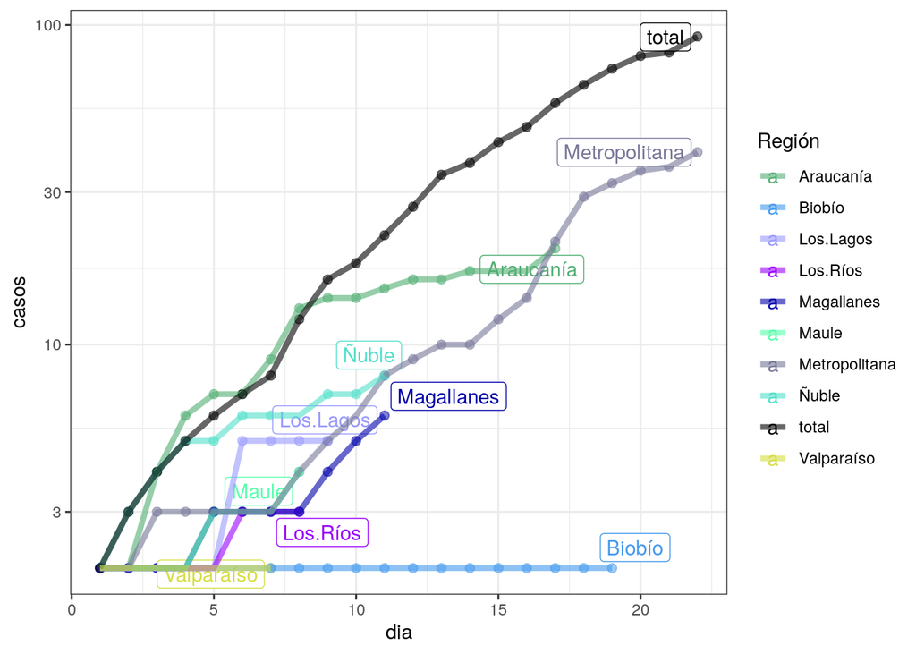

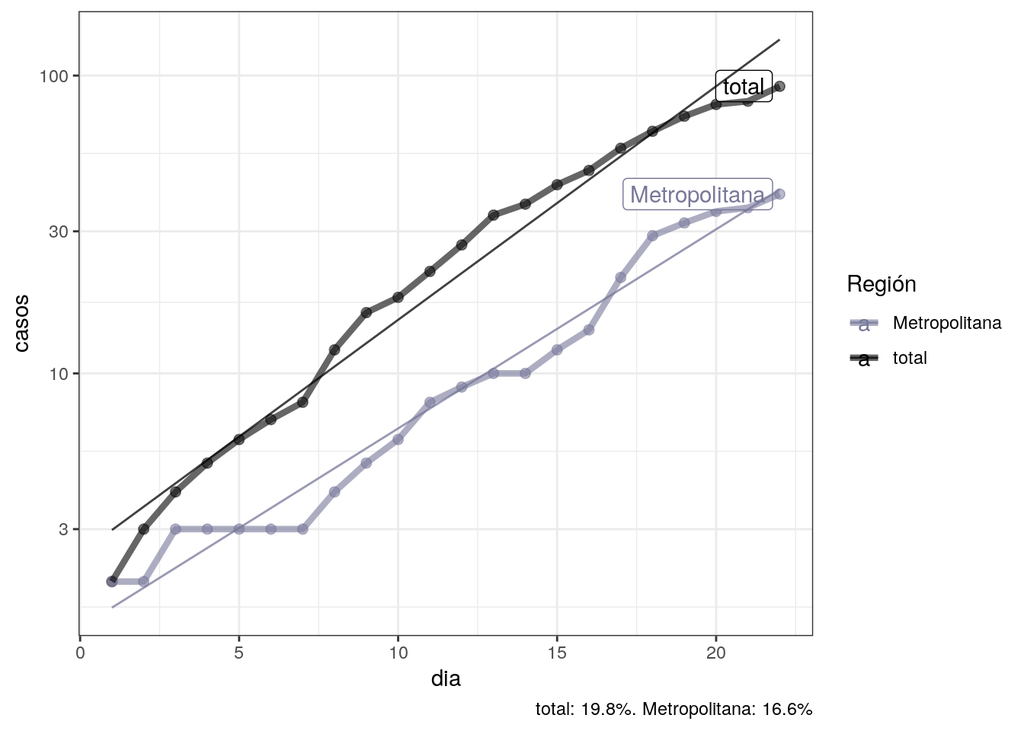

**Fuentes de información**: Principalmente, se utilizó el reporte diario del [MINSAL](https://www.minsal.cl/nuevo-coronavirus-2019-ncov/casos-confirmados-en-chile-covid-19/), usando [Wayback machine](https://archive.org/web/) para recopilar la información ya no disponible.

## Anexo I: Predicciones por región

Casos nuevos: tendencia + AR(1) : Arica.y.Parinacota

|  | dia | casos | li | ls |
| --- | --- | --- | --- | --- |
| **21** | 43 | 124.5 | 120.8 | 147.2 |
| **22** | 44 | 128.3 | 121.4 | 170.2 |
| **23** | 45 | 131.3 | 121.8 | 188.7 |
| **24** | 46 | 133.6 | 122.2 | 203 |
| **25** | 47 | 135.4 | 122.5 | 213.8 |
| **26** | 48 | 136.7 | 122.7 | 221.7 |
| **27** | 49 | 137.6 | 122.9 | 227.3 |

Casos nuevos: tendencia + AR(1) : Tarapacá

|  | dia | casos | li | ls |
| --- | --- | --- | --- | --- |
| **23** | 43 | 71.4 | 66.28 | 82.62 |
| **24** | 44 | 83.84 | 71.78 | 110.8 |
| **25** | 45 | 98.97 | 78.45 | 145.1 |
| **26** | 46 | 118 | 86.85 | 188.4 |
| **27** | 47 | 142.1 | 97.46 | 243 |
| **28** | 48 | 172.8 | 111 | 312.7 |
| **29** | 49 | 212.4 | 128.4 | 402.5 |

Casos nuevos: tendencia + AR(1) : Antofagasta

|  | dia | casos | li | ls |
| --- | --- | --- | --- | --- |
| **27** | 43 | 174.8 | 158.9 | 255.4 |
| **28** | 44 | 192.4 | 162.2 | 349.6 |
| **29** | 45 | 214.4 | 166.3 | 467.3 |
| **30** | 46 | 239.7 | 171 | 602.9 |
| **31** | 47 | 269.6 | 176.6 | 763.1 |
| **32** | 48 | 304.9 | 183.2 | 952.2 |
| **33** | 49 | 346.9 | 191 | 1177 |

Casos nuevos: tendencia + AR(1) : Atacama

|  | dia | casos | li | ls |
| --- | --- | --- | --- | --- |
| **15** | 43 | 13.85 | 13.37 | 14.94 |
| **16** | 44 | 14.57 | 13.69 | 16.59 |
| **17** | 45 | 15.16 | 13.95 | 17.95 |
| **18** | 46 | 15.64 | 14.15 | 19.06 |
| **19** | 47 | 16.02 | 14.32 | 19.93 |
| **20** | 48 | 16.32 | 14.45 | 20.6 |
| **21** | 49 | 16.54 | 14.54 | 21.11 |

Casos nuevos: tendencia + AR(1) : Coquimbo

|  | dia | casos | li | ls |
| --- | --- | --- | --- | --- |
| **27** | 43 | 67.24 | 66.27 | 71.73 |
| **28** | 44 | 68.26 | 66.48 | 76.58 |
| **29** | 45 | 69.16 | 66.67 | 80.81 |
| **30** | 46 | 69.92 | 66.83 | 84.43 |
| **31** | 47 | 70.57 | 66.97 | 87.5 |
| **32** | 48 | 71.12 | 67.09 | 90.08 |
| **33** | 49 | 71.57 | 67.18 | 92.21 |

Casos nuevos: tendencia + AR(1) : Valparaíso

|  | dia | casos | li | ls |
| --- | --- | --- | --- | --- |
| **28** | 43 | 290.3 | 286.6 | 302.2 |
| **29** | 44 | 295.4 | 288.1 | 319.5 |
| **30** | 45 | 299.6 | 289.4 | 333.7 |
| **31** | 46 | 303.2 | 290.4 | 345.5 |
| **32** | 47 | 306.1 | 291.3 | 355.2 |
| **33** | 48 | 308.4 | 292 | 363.1 |
| **34** | 49 | 310.2 | 292.6 | 369.3 |

Casos nuevos: tendencia + AR(1) : Metropolitana

|  | dia | casos | li | ls |
| --- | --- | --- | --- | --- |
| **36** | 36 | 4278 | 4163 | 4566 |
| **37** | 37 | 4446 | 4229 | 4995 |
| **38** | 38 | 4601 | 4289 | 5391 |
| **39** | 39 | 4744 | 4345 | 5755 |
| **40** | 40 | 4875 | 4397 | 6090 |
| **41** | 41 | 4994 | 4443 | 6394 |
| **42** | 42 | 5101 | 4485 | 6668 |

Casos nuevos: tendencia + AR(1) : O’Higgins

|  | dia | casos | li | ls |
| --- | --- | --- | --- | --- |
| **27** | 43 | 54.98 | 53.56 | 59.98 |
| **28** | 44 | 56.49 | 53.97 | 65.53 |
| **29** | 45 | 57.85 | 54.34 | 70.54 |
| **30** | 46 | 59.12 | 54.69 | 75.21 |
| **31** | 47 | 60.31 | 55.01 | 79.59 |
| **32** | 48 | 61.43 | 55.32 | 83.7 |
| **33** | 49 | 62.47 | 55.6 | 87.54 |

Casos nuevos: tendencia + AR(1) : Maule

|  | dia | casos | li | ls |
| --- | --- | --- | --- | --- |
| **36** | 36 | 144 | 142.4 | 151.3 |
| **37** | 37 | 146.2 | 142.9 | 162.2 |
| **38** | 38 | 148.2 | 143.3 | 172.7 |
| **39** | 39 | 150.1 | 143.7 | 182.1 |
| **40** | 40 | 151.8 | 144 | 190.6 |
| **41** | 41 | 153.3 | 144.3 | 198.1 |
| **42** | 42 | 154.6 | 144.6 | 204.7 |

Casos nuevos: tendencia + AR(1) : Ñuble

|  | dia | casos | li | ls |
| --- | --- | --- | --- | --- |
| **32** | 43 | 627.1 | 623.1 | 644.5 |
| **33** | 44 | 630.9 | 624 | 661.8 |
| **34** | 45 | 633.8 | 624.7 | 674.8 |
| **35** | 46 | 636 | 625.1 | 684.4 |
| **36** | 47 | 637.6 | 625.5 | 691.4 |
| **37** | 48 | 638.7 | 625.7 | 696.3 |
| **38** | 49 | 639.5 | 625.9 | 699.8 |

Casos nuevos: tendencia + AR(1) : Biobío

|  | dia | casos | li | ls |
| --- | --- | --- | --- | --- |
| **33** | 36 | 535 | 530.8 | 545.9 |
| **34** | 37 | 540.6 | 532.9 | 560 |
| **35** | 38 | 544.8 | 534.6 | 570.7 |
| **36** | 39 | 548 | 535.9 | 578.8 |
| **37** | 40 | 550.3 | 536.8 | 584.8 |
| **38** | 41 | 552 | 537.4 | 589 |
| **39** | 42 | 553.2 | 537.9 | 592.1 |

Casos nuevos: tendencia + AR(1) : Araucanía

|  | dia | casos | li | ls |
| --- | --- | --- | --- | --- |
| **28** | 43 | 828.9 | 822.6 | 841.1 |
| **29** | 44 | 838.5 | 827.6 | 859.9 |
| **30** | 45 | 845.8 | 831.3 | 874 |
| **31** | 46 | 851.1 | 834 | 884.4 |
| **32** | 47 | 854.9 | 836 | 891.9 |
| **33** | 48 | 857.6 | 837.4 | 897.1 |
| **34** | 49 | 859.5 | 838.3 | 900.7 |

Casos nuevos: tendencia + AR(1) : Los.Ríos

|  | dia | casos | li | ls |
| --- | --- | --- | --- | --- |
| **24** | 43 | 151 | 149.2 | 155.4 |
| **25** | 44 | 154.2 | 150.5 | 163.3 |
| **26** | 45 | 156.8 | 151.5 | 169.8 |
| **27** | 46 | 159 | 152.4 | 175.4 |
| **28** | 47 | 160.9 | 153.2 | 180.1 |
| **29** | 48 | 162.4 | 153.8 | 183.9 |
| **30** | 49 | 163.7 | 154.3 | 187.1 |

Casos nuevos: tendencia + AR(1) : Los.Lagos

|  | dia | casos | li | ls |
| --- | --- | --- | --- | --- |
| **28** | 36 | 389.1 | 386.7 | 394.7 |
| **29** | 37 | 392 | 387.8 | 402.2 |
| **30** | 38 | 394.1 | 388.6 | 407.8 |
| **31** | 39 | 395.5 | 389.2 | 411.6 |
| **32** | 40 | 396.5 | 389.6 | 414.3 |
| **33** | 41 | 397.2 | 389.8 | 416.1 |
| **34** | 42 | 397.6 | 390 | 417.2 |

Casos nuevos: tendencia + AR(1) : Aysén

|  | dia | casos | li | ls |
| --- | --- | --- | --- | --- |
| **15** | 43 | 8.18 | 7.87 | 8.61 |
| **16** | 44 | 9.41 | 8.75 | 10.32 |
| **17** | 45 | 10.76 | 9.72 | 12.21 |
| **18** | 46 | 12.26 | 10.79 | 14.3 |
| **19** | 47 | 13.93 | 11.98 | 16.64 |
| **20** | 48 | 15.82 | 13.34 | 19.28 |
| **21** | 49 | 18 | 14.89 | 22.32 |

Casos nuevos: tendencia + AR(1) : Magallanes

|  | dia | casos | li | ls |
| --- | --- | --- | --- | --- |
| **26** | 43 | 448.6 | 434.2 | 503.3 |
| **27** | 44 | 464.1 | 438.1 | 563.8 |
| **28** | 45 | 477.6 | 441.6 | 617.1 |
| **29** | 46 | 488.9 | 444.4 | 661.6 |
| **30** | 47 | 498.3 | 446.8 | 698.3 |
| **31** | 48 | 505.8 | 448.7 | 728 |
| **32** | 49 | 511.8 | 450.2 | 751.4 |

ARIMA(1,1,0) con deriva : Arica.y.Parinacota

|  | dia | casos | li | ls |
| --- | --- | --- | --- | --- |
| **21** | 43 | 145.1 | 92.31 | 228.2 |
| **22** | 44 | 176.1 | 92.17 | 336.6 |
| **23** | 45 | 213.8 | 96.4 | 474.1 |
| **24** | 46 | 259.5 | 103.2 | 652 |
| **25** | 47 | 314.9 | 112.3 | 883.5 |
| **26** | 48 | 382.2 | 123.4 | 1184 |
| **27** | 49 | 463.9 | 136.7 | 1575 |

ARIMA(1,1,0) con deriva : Tarapacá

|  | dia | casos | li | ls |
| --- | --- | --- | --- | --- |
| **23** | 43 | 70.21 | 58.83 | 83.79 |
| **24** | 44 | 80.12 | 63.52 | 101 |
| **25** | 45 | 91.33 | 69.11 | 120.7 |
| **26** | 46 | 104.1 | 75.73 | 143.1 |
| **27** | 47 | 118.7 | 83.35 | 169 |
| **28** | 48 | 135.3 | 92.02 | 199 |
| **29** | 49 | 154.3 | 101.9 | 233.6 |

ARIMA(1,1,0) con deriva : Antofagasta

|  | dia | casos | li | ls |
| --- | --- | --- | --- | --- |
| **27** | 43 | 179.5 | 142.3 | 226.4 |
| **28** | 44 | 203.2 | 151.2 | 273.1 |
| **29** | 45 | 231.1 | 162.3 | 329.1 |
| **30** | 46 | 262.7 | 175.7 | 392.6 |
| **31** | 47 | 298.5 | 191.2 | 466.1 |
| **32** | 48 | 339.3 | 208.9 | 551.1 |
| **33** | 49 | 385.7 | 228.9 | 649.7 |

ARIMA(1,1,0) con deriva : Atacama

|  | dia | casos | li | ls |
| --- | --- | --- | --- | --- |
| **15** | 43 | 14.57 | 10.37 | 20.46 |
| **16** | 44 | 16.31 | 10.11 | 26.31 |
| **17** | 45 | 18.26 | 10.18 | 32.77 |
| **18** | 46 | 20.45 | 10.41 | 40.14 |
| **19** | 47 | 22.89 | 10.77 | 48.65 |
| **20** | 48 | 25.63 | 11.22 | 58.51 |
| **21** | 49 | 28.69 | 11.76 | 69.97 |

ARIMA(1,1,0) con deriva : Coquimbo

|  | dia | casos | li | ls |
| --- | --- | --- | --- | --- |
| **27** | 43 | 74.01 | 53.83 | 101.7 |
| **28** | 44 | 83.64 | 52.5 | 133.2 |
| **29** | 45 | 94.58 | 53.09 | 168.5 |
| **30** | 46 | 107 | 54.67 | 209.2 |
| **31** | 47 | 120.9 | 56.96 | 256.8 |
| **32** | 48 | 136.8 | 59.82 | 312.6 |
| **33** | 49 | 154.6 | 63.22 | 378.3 |

ARIMA(1,1,0) con deriva : Valparaíso

|  | dia | casos | li | ls |
| --- | --- | --- | --- | --- |
| **28** | 43 | 326.8 | 225.1 | 474.6 |
| **29** | 44 | 382.6 | 212.4 | 689.2 |
| **30** | 45 | 450 | 211.5 | 957.5 |
| **31** | 46 | 529.7 | 216.8 | 1294 |
| **32** | 47 | 623.7 | 226.5 | 1718 |
| **33** | 48 | 734.5 | 239.6 | 2252 |
| **34** | 49 | 864.8 | 255.8 | 2924 |

ARIMA(1,1,0) con deriva : Metropolitana

|  | dia | casos | li | ls |
| --- | --- | --- | --- | --- |
| **36** | 36 | 4666 | 3481 | 6254 |
| **37** | 37 | 5468 | 3283 | 9109 |
| **38** | 38 | 6480 | 3236 | 12978 |
| **39** | 39 | 7715 | 3291 | 18090 |
| **40** | 40 | 9205 | 3421 | 24765 |
| **41** | 41 | 10991 | 3614 | 33427 |
| **42** | 42 | 13128 | 3863 | 44618 |

ARIMA(1,1,0) con deriva : O’Higgins

|  | dia | casos | li | ls |
| --- | --- | --- | --- | --- |
| **27** | 43 | 58.17 | 50.54 | 66.95 |
| **28** | 44 | 63.69 | 50.03 | 81.07 |
| **29** | 45 | 69.67 | 50.32 | 96.45 |
| **30** | 46 | 76.18 | 51.24 | 113.2 |
| **31** | 47 | 83.29 | 52.65 | 131.7 |
| **32** | 48 | 91.05 | 54.47 | 152.2 |
| **33** | 49 | 99.54 | 56.64 | 174.9 |

ARIMA(1,1,0) con deriva : Maule

|  | dia | casos | li | ls |
| --- | --- | --- | --- | --- |
| **36** | 36 | 157.4 | 123.6 | 200.5 |
| **37** | 37 | 173.6 | 124.4 | 242.3 |
| **38** | 38 | 191.5 | 127.8 | 287.1 |
| **39** | 39 | 211.3 | 132.7 | 336.5 |
| **40** | 40 | 233.1 | 138.7 | 391.7 |
| **41** | 41 | 257.2 | 145.8 | 453.6 |
| **42** | 42 | 283.7 | 153.8 | 523.3 |

ARIMA(1,1,0) con deriva : Ñuble

|  | dia | casos | li | ls |
| --- | --- | --- | --- | --- |
| **32** | 43 | 698.1 | 445.1 | 1095 |
| **33** | 44 | 810.2 | 386.5 | 1698 |
| **34** | 45 | 949.8 | 359.4 | 2510 |
| **35** | 46 | 1117 | 348.4 | 3582 |
| **36** | 47 | 1315 | 346.9 | 4984 |
| **37** | 48 | 1548 | 351.9 | 6813 |
| **38** | 49 | 1823 | 361.8 | 9187 |

ARIMA(1,1,0) con deriva : Biobío

|  | dia | casos | li | ls |
| --- | --- | --- | --- | --- |
| **33** | 36 | 612.9 | 383.7 | 978.9 |
| **34** | 37 | 721.7 | 357.1 | 1459 |
| **35** | 38 | 851.4 | 352.3 | 2057 |
| **36** | 39 | 1005 | 358.3 | 2816 |
| **37** | 40 | 1185 | 371.4 | 3783 |
| **38** | 41 | 1398 | 390 | 5015 |
| **39** | 42 | 1650 | 413.5 | 6585 |

ARIMA(1,1,0) con deriva : Araucanía

|  | dia | casos | li | ls |
| --- | --- | --- | --- | --- |
| **28** | 43 | 860.8 | 720.1 | 1029 |
| **29** | 44 | 928.6 | 641.7 | 1344 |
| **30** | 45 | 1020 | 573.6 | 1813 |
| **31** | 46 | 1137 | 517.5 | 2497 |
| **32** | 47 | 1282 | 472.5 | 3480 |
| **33** | 48 | 1460 | 437 | 4881 |
| **34** | 49 | 1677 | 409.5 | 6864 |

ARIMA(1,1,0) con deriva : Los.Ríos

|  | dia | casos | li | ls |
| --- | --- | --- | --- | --- |
| **24** | 43 | 165 | 127.8 | 213.2 |
| **25** | 44 | 188.6 | 115.7 | 307.2 |
| **26** | 45 | 218.7 | 107.5 | 445 |
| **27** | 46 | 256.2 | 102.5 | 640 |
| **28** | 47 | 301.8 | 100 | 910.5 |
| **29** | 48 | 356.9 | 99.51 | 1280 |
| **30** | 49 | 423 | 100.6 | 1778 |

ARIMA(1,1,0) con deriva : Los.Lagos

|  | dia | casos | li | ls |
| --- | --- | --- | --- | --- |
| **28** | 36 | 427.8 | 349.2 | 524 |
| **29** | 37 | 481.9 | 353.8 | 656.4 |
| **30** | 38 | 544 | 368.4 | 803.4 |
| **31** | 39 | 614.3 | 389 | 970.1 |
| **32** | 40 | 693.7 | 414.3 | 1162 |
| **33** | 41 | 783.4 | 443.9 | 1382 |
| **34** | 42 | 884.6 | 477.8 | 1638 |

ARIMA(1,1,0) con deriva : Aysén

|  | dia | casos | li | ls |
| --- | --- | --- | --- | --- |
| **15** | 43 | 7.23 | 5.58 | 9.36 |
| **16** | 44 | 7.64 | 4.54 | 12.85 |
| **17** | 45 | 8.21 | 3.73 | 18.11 |
| **18** | 46 | 8.95 | 3.11 | 25.77 |
| **19** | 47 | 9.85 | 2.64 | 36.68 |
| **20** | 48 | 10.92 | 2.29 | 51.99 |
| **21** | 49 | 12.17 | 2.02 | 73.17 |

ARIMA(1,1,0) con deriva : Magallanes

|  | dia | casos | li | ls |
| --- | --- | --- | --- | --- |
| **26** | 43 | 502.3 | 372.1 | 678 |
| **27** | 44 | 608.7 | 374.2 | 990 |
| **28** | 45 | 744.7 | 395.2 | 1403 |
| **29** | 46 | 913.6 | 429 | 1945 |
| **30** | 47 | 1122 | 473.7 | 2655 |
| **31** | 48 | 1377 | 529.2 | 3583 |
| **32** | 49 | 1691 | 596.2 | 4795 |